# Risk Factor Analysis

## Outcome Variable

**Outcome Variable:** whz

## Predictor Variables

**Intervention Variable:** fage

**Adjustment Set:**

unadjusted

## Stratifying Variables

The analysis was stratified on these variable(s):

- agecat
- studyid
- country

## Data Summary

| agecat | studyid | country | fage | n_cell | n |
| --- | --- | --- | --- | --- | --- |
| Birth | COHORTS | GUATEMALA | >=38 | 222 | 735 |
| Birth | COHORTS | GUATEMALA | <32 | 337 | 735 |
| Birth | COHORTS | GUATEMALA | [32-38) | 176 | 735 |
| Birth | COHORTS | PHILIPPINES | >=38 | 303 | 2797 |
| Birth | COHORTS | PHILIPPINES | <32 | 1981 | 2797 |
| Birth | COHORTS | PHILIPPINES | [32-38) | 513 | 2797 |
| Birth | MAL-ED | BANGLADESH | >=38 | 61 | 128 |
| Birth | MAL-ED | BANGLADESH | <32 | 23 | 128 |
| Birth | MAL-ED | BANGLADESH | [32-38) | 44 | 128 |
| Birth | MAL-ED | BRAZIL | >=38 | 5 | 16 |
| Birth | MAL-ED | BRAZIL | <32 | 1 | 16 |
| Birth | MAL-ED | BRAZIL | [32-38) | 10 | 16 |
| Birth | MAL-ED | INDIA | >=38 | 7 | 25 |
| Birth | MAL-ED | INDIA | <32 | 8 | 25 |
| Birth | MAL-ED | INDIA | [32-38) | 10 | 25 |
| Birth | MAL-ED | NEPAL | >=38 | 2 | 9 |
| Birth | MAL-ED | NEPAL | <32 | 2 | 9 |
| Birth | MAL-ED | NEPAL | [32-38) | 5 | 9 |
| Birth | MAL-ED | PERU | >=38 | 23 | 67 |
| Birth | MAL-ED | PERU | <32 | 21 | 67 |
| Birth | MAL-ED | PERU | [32-38) | 23 | 67 |
| Birth | MAL-ED | SOUTH AFRICA | >=38 | 16 | 30 |
| Birth | MAL-ED | SOUTH AFRICA | <32 | 5 | 30 |
| Birth | MAL-ED | SOUTH AFRICA | [32-38) | 9 | 30 |
| Birth | MAL-ED | TANZANIA, UNITED REPUBLIC OF | >=38 | 17 | 44 |
| Birth | MAL-ED | TANZANIA, UNITED REPUBLIC OF | <32 | 9 | 44 |
| Birth | MAL-ED | TANZANIA, UNITED REPUBLIC OF | [32-38) | 18 | 44 |
| Birth | PROBIT | BELARUS | >=38 | 604 | 13325 |
| Birth | PROBIT | BELARUS | <32 | 10671 | 13325 |
| Birth | PROBIT | BELARUS | [32-38) | 2050 | 13325 |

[output cut: 75 more lines]

The following strata were considered:

- agecat: 24 months, studyid: COHORTS, country: GUATEMALA
- agecat: 24 months, studyid: COHORTS, country: PHILIPPINES
- agecat: 24 months, studyid: LCNI-5, country: MALAWI
- agecat: 24 months, studyid: MAL-ED, country: BANGLADESH
- agecat: 24 months, studyid: MAL-ED, country: BRAZIL
- agecat: 24 months, studyid: MAL-ED, country: INDIA
- agecat: 24 months, studyid: MAL-ED, country: NEPAL
- agecat: 24 months, studyid: MAL-ED, country: PERU
- agecat: 24 months, studyid: MAL-ED, country: SOUTH AFRICA
- agecat: 24 months, studyid: MAL-ED, country: TANZANIA, UNITED REPUBLIC OF
- agecat: 24 months, studyid: PROBIT, country: BELARUS
- agecat: 6 months, studyid: COHORTS, country: GUATEMALA
- agecat: 6 months, studyid: COHORTS, country: PHILIPPINES
- agecat: 6 months, studyid: LCNI-5, country: MALAWI
- agecat: 6 months, studyid: MAL-ED, country: BANGLADESH
- agecat: 6 months, studyid: MAL-ED, country: BRAZIL
- agecat: 6 months, studyid: MAL-ED, country: INDIA
- agecat: 6 months, studyid: MAL-ED, country: NEPAL
- agecat: 6 months, studyid: MAL-ED, country: PERU
- agecat: 6 months, studyid: MAL-ED, country: SOUTH AFRICA
- agecat: 6 months, studyid: MAL-ED, country: TANZANIA, UNITED REPUBLIC OF
- agecat: 6 months, studyid: PROBIT, country: BELARUS
- agecat: 6 months, studyid: SAS-CompFeed, country: INDIA
- agecat: 6 months, studyid: SAS-FoodSuppl, country: INDIA
- agecat: Birth, studyid: COHORTS, country: GUATEMALA
- agecat: Birth, studyid: COHORTS, country: PHILIPPINES
- agecat: Birth, studyid: MAL-ED, country: BANGLADESH
- agecat: Birth, studyid: MAL-ED, country: BRAZIL
- agecat: Birth, studyid: MAL-ED, country: INDIA
- agecat: Birth, studyid: MAL-ED, country: NEPAL
- agecat: Birth, studyid: MAL-ED, country: PERU
- agecat: Birth, studyid: MAL-ED, country: SOUTH AFRICA
- agecat: Birth, studyid: MAL-ED, country: TANZANIA, UNITED REPUBLIC OF
- agecat: Birth, studyid: PROBIT, country: BELARUS
- agecat: Birth, studyid: SAS-CompFeed, country: INDIA

### Dropped Strata

Some strata were dropped due to rare outcomes:

- agecat: Birth, studyid: MAL-ED, country: BRAZIL
- agecat: Birth, studyid: MAL-ED, country: NEPAL

## Methods Detail

We’re interested in the causal parameters $E[Y_a]$ for all values of $a \in \mathcal{A}$. These parameters represent the mean outcome if, possibly contrary to fact, we intervened to set all units to have $A=a$. Under the randomization and positivity assumptions, these are identified by the statistical parameters $\psi_a=E_W[E_{Y|A,W}(Y|A=a,W)]$. In addition, we’re interested in the mean of $Y$, $E[Y]$ under no intervention (the observed mean). We will estimate these parameters by using SuperLearner to fit the relevant likelihood factors – $E_{Y|A,W}(Y|A=a,W)$ and $p(A=a|W)$, and then updating our likelihood fit using a joint TMLE.

For unadjusted analyses ($W=\{\}$), initial likelihoods were estimated using Lrnr_glm to estimate the simple $E(Y|A)$ and Lrnr_mean to estimate $p(A)$. For adjusted analyses, a small library containing Lrnr_glmnet, Lrnr_xgboost, and Lrnr_mean was used.

Having estimated these parameters, we will then use the delta method to estimate relative risks and attributable risks relative to a prespecified baseline level of $A$.

# Results Detail

## Results Plots

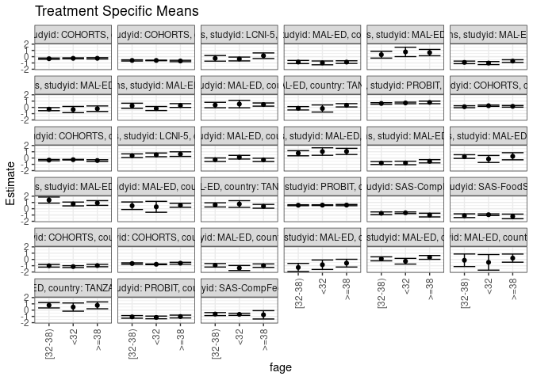

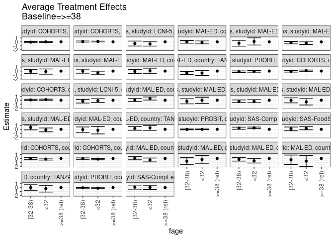

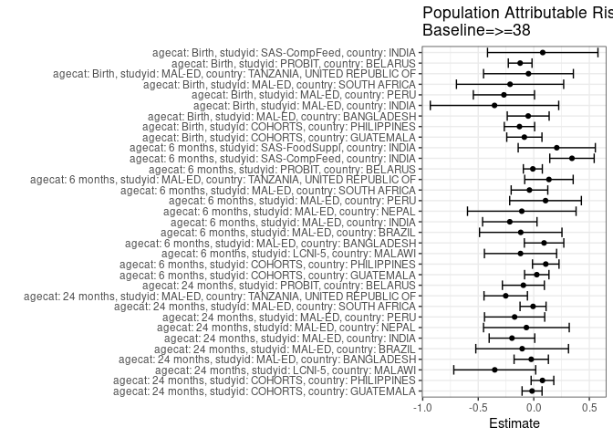

## Results Table

### Parameter: TSM

| agecat | studyid | country | intervention_level | baseline_level | estimate | ci_lower | ci_upper |
| --- | --- | --- | --- | --- | --- | --- | --- |
| Birth | COHORTS | GUATEMALA | >=38 | NA | -0.9731982 | -1.1649178 | -0.7814786 |
| Birth | COHORTS | GUATEMALA | <32 | NA | -1.1410386 | -1.2891827 | -0.9928945 |
| Birth | COHORTS | GUATEMALA | [32-38) | NA | -1.0061364 | -1.2166885 | -0.7955842 |
| Birth | COHORTS | PHILIPPINES | >=38 | NA | -0.6020792 | -0.7470952 | -0.4570633 |
| Birth | COHORTS | PHILIPPINES | <32 | NA | -0.7714891 | -0.8271174 | -0.7158609 |
| Birth | COHORTS | PHILIPPINES | [32-38) | NA | -0.6506628 | -0.7615030 | -0.5398226 |
| Birth | MAL-ED | BANGLADESH | >=38 | NA | -0.9872131 | -1.2609710 | -0.7134552 |
| Birth | MAL-ED | BANGLADESH | <32 | NA | -1.3678261 | -1.7732621 | -0.9623900 |
| Birth | MAL-ED | BANGLADESH | [32-38) | NA | -0.9345455 | -1.2101307 | -0.6589602 |
| Birth | MAL-ED | INDIA | >=38 | NA | -0.5928571 | -1.2084707 | 0.0227564 |
| Birth | MAL-ED | INDIA | <32 | NA | -0.8425000 | -1.5949041 | -0.0900959 |
| Birth | MAL-ED | INDIA | [32-38) | NA | -1.2770000 | -1.9214891 | -0.6325109 |
| Birth | MAL-ED | PERU | >=38 | NA | 0.3217391 | 0.0163233 | 0.6271550 |
| Birth | MAL-ED | PERU | <32 | NA | -0.2857143 | -0.7402315 | 0.1688029 |
| Birth | MAL-ED | PERU | [32-38) | NA | 0.0934783 | -0.2219705 | 0.4089270 |
| Birth | MAL-ED | SOUTH AFRICA | >=38 | NA | 0.2062500 | -0.4416802 | 0.8541802 |
| Birth | MAL-ED | SOUTH AFRICA | <32 | NA | -0.4600000 | -1.7036186 | 0.7836186 |
| Birth | MAL-ED | SOUTH AFRICA | [32-38) | NA | -0.1355556 | -1.1366672 | 0.8655561 |
| Birth | MAL-ED | TANZANIA, UNITED REPUBLIC OF | >=38 | NA | 0.7594118 | 0.2105891 | 1.3082344 |
| Birth | MAL-ED | TANZANIA, UNITED REPUBLIC OF | <32 | NA | 0.4877778 | -0.1646330 | 1.1401886 |
| Birth | MAL-ED | TANZANIA, UNITED REPUBLIC OF | [32-38) | NA | 0.7783333 | 0.3478361 | 1.2088306 |
| Birth | PROBIT | BELARUS | >=38 | NA | -1.0209934 | -1.2471190 | -0.7948678 |
| Birth | PROBIT | BELARUS | <32 | NA | -1.1637738 | -1.3759970 | -0.9515505 |
| Birth | PROBIT | BELARUS | [32-38) | NA | -1.0751488 | -1.2865500 | -0.8637476 |
| Birth | SAS-CompFeed | INDIA | >=38 | NA | -0.7491176 | -1.4133975 | -0.0848378 |
| Birth | SAS-CompFeed | INDIA | <32 | NA | -0.6719177 | -0.8352679 | -0.5085674 |
| Birth | SAS-CompFeed | INDIA | [32-38) | NA | -0.6279167 | -0.8655348 | -0.3902986 |
| 6 months | COHORTS | GUATEMALA | >=38 | NA | 0.1657246 | 0.0360663 | 0.2953830 |
| 6 months | COHORTS | GUATEMALA | <32 | NA | 0.2604038 | 0.1560169 | 0.3647907 |
| 6 months | COHORTS | GUATEMALA | [32-38) | NA | 0.1018884 | -0.0508822 | 0.2546591 |

[output cut: 69 more lines]

### Parameter: E(Y)

| agecat | studyid | country | intervention_level | baseline_level | estimate | ci_lower | ci_upper |
| --- | --- | --- | --- | --- | --- | --- | --- |
| Birth | COHORTS | GUATEMALA | NA | NA | -1.0580408 | -1.1607065 | -0.9553751 |
| Birth | COHORTS | PHILIPPINES | NA | NA | -0.7309760 | -0.7780724 | -0.6838797 |
| Birth | MAL-ED | BANGLADESH | NA | NA | -1.0375000 | -1.2165024 | -0.8584976 |
| Birth | MAL-ED | INDIA | NA | NA | -0.9464000 | -1.3554144 | -0.5373856 |
| Birth | MAL-ED | PERU | NA | NA | 0.0529851 | -0.1628445 | 0.2688147 |
| Birth | MAL-ED | SOUTH AFRICA | NA | NA | -0.0073333 | -0.5181900 | 0.5035233 |
| Birth | MAL-ED | TANZANIA, UNITED REPUBLIC OF | NA | NA | 0.7115909 | 0.4034609 | 1.0197209 |
| Birth | PROBIT | BELARUS | NA | NA | -1.1436672 | -1.3543559 | -0.9329784 |
| Birth | SAS-CompFeed | INDIA | NA | NA | -0.6685468 | -0.8459689 | -0.4911247 |
| 6 months | COHORTS | GUATEMALA | NA | NA | 0.1925914 | 0.1205037 | 0.2646791 |
| 6 months | COHORTS | PHILIPPINES | NA | NA | -0.2878032 | -0.3296319 | -0.2459745 |
| 6 months | LCNI-5 | MALAWI | NA | NA | 0.5060377 | 0.3131397 | 0.6989358 |
| 6 months | MAL-ED | BANGLADESH | NA | NA | -0.1950111 | -0.3575506 | -0.0324716 |
| 6 months | MAL-ED | BRAZIL | NA | NA | 0.9365401 | 0.6541549 | 1.2189253 |
| 6 months | MAL-ED | INDIA | NA | NA | -0.7292288 | -0.8803893 | -0.5780683 |
| 6 months | MAL-ED | NEPAL | NA | NA | 0.1749789 | -0.0644624 | 0.4144202 |
| 6 months | MAL-ED | PERU | NA | NA | 1.0182129 | 0.7827641 | 1.2536616 |
| 6 months | MAL-ED | SOUTH AFRICA | NA | NA | 0.5158052 | 0.2517895 | 0.7798210 |
| 6 months | MAL-ED | TANZANIA, UNITED REPUBLIC OF | NA | NA | 0.5271500 | 0.3177522 | 0.7365478 |
| 6 months | PROBIT | BELARUS | NA | NA | 0.5731698 | 0.5135069 | 0.6328327 |
| 6 months | SAS-CompFeed | INDIA | NA | NA | -0.6641059 | -0.8040033 | -0.5242086 |
| 6 months | SAS-FoodSuppl | INDIA | NA | NA | -1.0121579 | -1.1280429 | -0.8962729 |
| 24 months | COHORTS | GUATEMALA | NA | NA | -0.2760853 | -0.3311930 | -0.2209775 |
| 24 months | COHORTS | PHILIPPINES | NA | NA | -0.6087584 | -0.6459824 | -0.5715345 |
| 24 months | LCNI-5 | MALAWI | NA | NA | -0.1979730 | -0.4244675 | 0.0285215 |
| 24 months | MAL-ED | BANGLADESH | NA | NA | -0.8844702 | -1.0263143 | -0.7426261 |
| 24 months | MAL-ED | BRAZIL | NA | NA | 0.5448101 | 0.2082313 | 0.8813890 |
| 24 months | MAL-ED | INDIA | NA | NA | -0.8968012 | -1.0287307 | -0.7648718 |
| 24 months | MAL-ED | NEPAL | NA | NA | -0.2794304 | -0.4767398 | -0.0821210 |
| 24 months | MAL-ED | PERU | NA | NA | 0.1198207 | -0.0845120 | 0.3241534 |
| 24 months | MAL-ED | SOUTH AFRICA | NA | NA | 0.4414045 | 0.2336389 | 0.6491701 |
| 24 months | MAL-ED | TANZANIA, UNITED REPUBLIC OF | NA | NA | 0.0766500 | -0.1115307 | 0.2648307 |
| 24 months | PROBIT | BELARUS | NA | NA | 0.6963019 | 0.5831245 | 0.8094793 |

### Parameter: ATE

| agecat | studyid | country | intervention_level | baseline_level | estimate | ci_lower | ci_upper |
| --- | --- | --- | --- | --- | --- | --- | --- |
| Birth | COHORTS | GUATEMALA | >=38 | >=38 | 0.0000000 | 0.0000000 | 0.0000000 |
| Birth | COHORTS | GUATEMALA | <32 | >=38 | -0.1678404 | -0.4101276 | 0.0744468 |
| Birth | COHORTS | GUATEMALA | [32-38) | >=38 | -0.0329382 | -0.3176988 | 0.2518225 |
| Birth | COHORTS | PHILIPPINES | >=38 | >=38 | 0.0000000 | 0.0000000 | 0.0000000 |
| Birth | COHORTS | PHILIPPINES | <32 | >=38 | -0.1694099 | -0.3247294 | -0.0140905 |
| Birth | COHORTS | PHILIPPINES | [32-38) | >=38 | -0.0485836 | -0.2311080 | 0.1339409 |
| Birth | MAL-ED | BANGLADESH | >=38 | >=38 | 0.0000000 | 0.0000000 | 0.0000000 |
| Birth | MAL-ED | BANGLADESH | <32 | >=38 | -0.3806130 | -0.8698182 | 0.1085923 |
| Birth | MAL-ED | BANGLADESH | [32-38) | >=38 | 0.0526677 | -0.3357788 | 0.4411141 |
| Birth | MAL-ED | INDIA | >=38 | >=38 | 0.0000000 | 0.0000000 | 0.0000000 |
| Birth | MAL-ED | INDIA | <32 | >=38 | -0.2496429 | -1.2218012 | 0.7225155 |
| Birth | MAL-ED | INDIA | [32-38) | >=38 | -0.6841429 | -1.5754039 | 0.2071182 |
| Birth | MAL-ED | PERU | >=38 | >=38 | 0.0000000 | 0.0000000 | 0.0000000 |
| Birth | MAL-ED | PERU | <32 | >=38 | -0.6074534 | -1.1550524 | -0.0598544 |
| Birth | MAL-ED | PERU | [32-38) | >=38 | -0.2282609 | -0.6673357 | 0.2108140 |
| Birth | MAL-ED | SOUTH AFRICA | >=38 | >=38 | 0.0000000 | 0.0000000 | 0.0000000 |
| Birth | MAL-ED | SOUTH AFRICA | <32 | >=38 | -0.6662500 | -2.0685341 | 0.7360341 |
| Birth | MAL-ED | SOUTH AFRICA | [32-38) | >=38 | -0.3418056 | -1.5342979 | 0.8506868 |
| Birth | MAL-ED | TANZANIA, UNITED REPUBLIC OF | >=38 | >=38 | 0.0000000 | 0.0000000 | 0.0000000 |
| Birth | MAL-ED | TANZANIA, UNITED REPUBLIC OF | <32 | >=38 | -0.2716340 | -1.1241867 | 0.5809187 |
| Birth | MAL-ED | TANZANIA, UNITED REPUBLIC OF | [32-38) | >=38 | 0.0189216 | -0.6785984 | 0.7164416 |
| Birth | PROBIT | BELARUS | >=38 | >=38 | 0.0000000 | 0.0000000 | 0.0000000 |
| Birth | PROBIT | BELARUS | <32 | >=38 | -0.1427804 | -0.2584906 | -0.0270702 |
| Birth | PROBIT | BELARUS | [32-38) | >=38 | -0.0541554 | -0.1561690 | 0.0478582 |
| Birth | SAS-CompFeed | INDIA | >=38 | >=38 | 0.0000000 | 0.0000000 | 0.0000000 |
| Birth | SAS-CompFeed | INDIA | <32 | >=38 | 0.0772000 | -0.4395832 | 0.5939832 |
| Birth | SAS-CompFeed | INDIA | [32-38) | >=38 | 0.1212010 | -0.3940199 | 0.6364219 |
| 6 months | COHORTS | GUATEMALA | >=38 | >=38 | 0.0000000 | 0.0000000 | 0.0000000 |
| 6 months | COHORTS | GUATEMALA | <32 | >=38 | 0.0946792 | -0.0717778 | 0.2611362 |
| 6 months | COHORTS | GUATEMALA | [32-38) | >=38 | -0.0638362 | -0.2642113 | 0.1365388 |

[output cut: 69 more lines]

### Parameter: PAR

| agecat | studyid | country | intervention_level | baseline_level | estimate | ci_lower | ci_upper |
| --- | --- | --- | --- | --- | --- | --- | --- |
| Birth | COHORTS | GUATEMALA | >=38 | NA | -0.0848426 | -0.2432496 | 0.0735644 |
| Birth | COHORTS | PHILIPPINES | >=38 | NA | -0.1288968 | -0.2656133 | 0.0078196 |
| Birth | MAL-ED | BANGLADESH | >=38 | NA | -0.0502869 | -0.2388468 | 0.1382730 |
| Birth | MAL-ED | INDIA | >=38 | NA | -0.3535429 | -0.9315083 | 0.2244226 |
| Birth | MAL-ED | PERU | >=38 | NA | -0.2687541 | -0.5441067 | 0.0065986 |
| Birth | MAL-ED | SOUTH AFRICA | >=38 | NA | -0.2135833 | -0.6962706 | 0.2691039 |
| Birth | MAL-ED | TANZANIA, UNITED REPUBLIC OF | >=38 | NA | -0.0478209 | -0.4520486 | 0.3564069 |
| Birth | PROBIT | BELARUS | >=38 | NA | -0.1226738 | -0.2294199 | -0.0159277 |
| Birth | SAS-CompFeed | INDIA | >=38 | NA | 0.0805709 | -0.4164965 | 0.5776382 |
| 6 months | COHORTS | GUATEMALA | >=38 | NA | 0.0268668 | -0.0828129 | 0.1365464 |
| 6 months | COHORTS | PHILIPPINES | >=38 | NA | 0.1077821 | -0.0116230 | 0.2271871 |
| 6 months | LCNI-5 | MALAWI | >=38 | NA | -0.1193469 | -0.4442900 | 0.2055962 |
| 6 months | MAL-ED | BANGLADESH | >=38 | NA | 0.0926217 | -0.0849284 | 0.2701718 |
| 6 months | MAL-ED | BRAZIL | >=38 | NA | -0.1173488 | -0.4883921 | 0.2536945 |
| 6 months | MAL-ED | INDIA | >=38 | NA | -0.2159417 | -0.4608516 | 0.0289681 |
| 6 months | MAL-ED | NEPAL | >=38 | NA | -0.1079623 | -0.5967140 | 0.3807895 |
| 6 months | MAL-ED | PERU | >=38 | NA | 0.1058054 | -0.2168778 | 0.4284887 |
| 6 months | MAL-ED | SOUTH AFRICA | >=38 | NA | -0.0388302 | -0.2037095 | 0.1260492 |
| 6 months | MAL-ED | TANZANIA, UNITED REPUBLIC OF | >=38 | NA | 0.1364556 | -0.0816815 | 0.3545926 |
| 6 months | PROBIT | BELARUS | >=38 | NA | -0.0085277 | -0.0939767 | 0.0769213 |
| 6 months | SAS-CompFeed | INDIA | >=38 | NA | 0.3438486 | 0.1440026 | 0.5436946 |
| 6 months | SAS-FoodSuppl | INDIA | >=38 | NA | 0.2068421 | -0.1404449 | 0.5541291 |
| 24 months | COHORTS | GUATEMALA | >=38 | NA | -0.0154929 | -0.1054222 | 0.0744363 |
| 24 months | COHORTS | PHILIPPINES | >=38 | NA | 0.0780313 | -0.0239722 | 0.1800347 |
| 24 months | LCNI-5 | MALAWI | >=38 | NA | -0.3513063 | -0.7201290 | 0.0175164 |
| 24 months | MAL-ED | BANGLADESH | >=38 | NA | -0.0228760 | -0.1773546 | 0.1316026 |
| 24 months | MAL-ED | BRAZIL | >=38 | NA | -0.1046899 | -0.5219642 | 0.3125844 |
| 24 months | MAL-ED | INDIA | >=38 | NA | -0.1963846 | -0.4017106 | 0.0089415 |
| 24 months | MAL-ED | NEPAL | >=38 | NA | -0.0664892 | -0.4521655 | 0.3191871 |
| 24 months | MAL-ED | PERU | >=38 | NA | -0.1726793 | -0.4435974 | 0.0982388 |
| 24 months | MAL-ED | SOUTH AFRICA | >=38 | NA | -0.0064929 | -0.1236499 | 0.1106640 |
| 24 months | MAL-ED | TANZANIA, UNITED REPUBLIC OF | >=38 | NA | -0.2526208 | -0.4480348 | -0.0572069 |
| 24 months | PROBIT | BELARUS | >=38 | NA | -0.0936981 | -0.2826682 | 0.0952719 |